# Effects of GoBike Users Behaviour on Its Demand

## by Oyebade James

## Investigation Overview

In this analysis, I investigated users' features and relate them to bike trips, which can be used to predict the demand for bikes. The main focus was on the members' age, gender, and user type, but the duration of trips, start time weekday of trips, and distance of trips were explored variables.

## Dataset Overview

The dataset provides trip records for the month of February, 2019 only. After some wangling efforts, there were 175,194 bike trips and 22 features in the dataset. The main features of interest are Trip Duration (seconds), Start Station Name, End Station Name, User Type (Subscriber or Customer – “Subscriber” = Member or “Customer” = Casual), Member GenderBike, Share For All Trip, Age Group, Trip Duration (minutes), Start Time (hours), Start Time Day of the WeekEnd Time (hours), End Time Day of the Week, and Distance (miles).

## Distribution of Bike Trip Duration (seconds)

Duration in seconds has a very large range of values. Plotted on a log-scale, the distribution takes on a unimodal shape and has a peak between 300 and 900. It is obvious that bike trips are usually within an hour mark (3600 seconds).

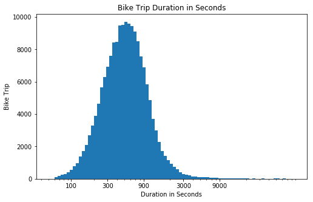

```python
# univariate plot of bike trip duration in second
log_binsize = 0.04
bins = 10 ** np.arange(1.7, np.log10(bike['duration_sec'].max())+log_binsize, log_binsize)

plt.figure(figsize=[8, 5])
plt.hist(data = bike, x = 'duration_sec', bins = bins)
plt.xscale('log')
plt.xticks([100, 300, 900, 3000, 9000], ['100', '300', '900', '3000', '9000'])
plt.xlabel('Duration in Seconds')
plt.ylabel('Bike Trip')
plt.title ('Bike Trip Duration in Seconds')
plt.show()
```

## Distribution of Bike Trip Duration (minutes)

The distribution has a long tailed end, where bike trips on average are between 4 and 10 minute range, with 75% of trips being under 14 minutes. This suggests that users are taking the bikes on short distances.

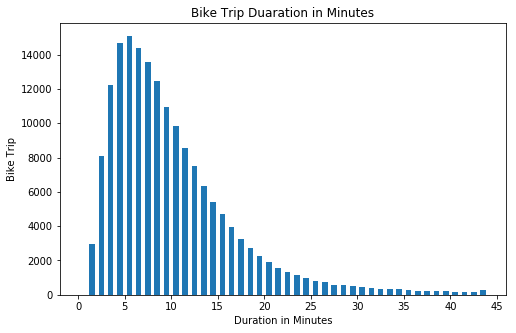

```python
# plotting with a different bin size and tick labels
bin_edges = np.arange(0, 45, 1)
ticks = [0, 5, 10, 15, 20, 25, 30,  35, 40, 45]
labels = ['{}'.format(val) for val in ticks]

plt.figure(figsize=[8, 5])
plt.hist(data = bike, x = 'duration_min', bins = bin_edges, rwidth = 0.6);

plt.title("Bike Trip Duaration in Minutes")
plt.xlabel('Duration in Minutes')
plt.ylabel('Bike Trip')
plt.xticks(ticks, labels)
plt.show()
```

75% of users are male, 23% are female and 2% are other gender.

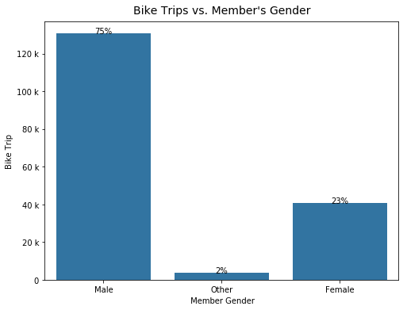

```python
# import necessary library
from matplotlib.ticker import EngFormatter


plt.figure(figsize = [8,6])
# create the plot
base_color = sb.color_palette()[0]
sb.countplot(data = bike, x = 'member_gender', color = base_color)
plt.title("Bike Trips vs. Member's Gender", fontsize=14, y=1.01)
plt.ylabel('Bike Trip')
plt.xlabel(" Member Gender")


# add annotations
n_points = bike.shape[0]
cat_counts = bike['member_gender'].value_counts()
locs, labels = plt.xticks() # get the current tick locations and labels

# loop through each pair of locations and labels
for loc, label in zip(locs, labels):

    ## get the text property for the label to get the correct count
    count = cat_counts[label.get_text()]
    pct_string = '{:0.0f}%'.format(100*count/n_points)


        # print the annotation just below the top of the bar
    plt.text(loc, count-8, pct_string, ha = 'center', color = 'black')

plt.gca().yaxis.set_major_formatter(EngFormatter())
```

## Distribution of Trip Distance (miles)

Trips are a mile on average, with users in the 3rd quartile ride about 1.38 miles. This reveals that on average, users go on a short trips, mostly under 2 miles.

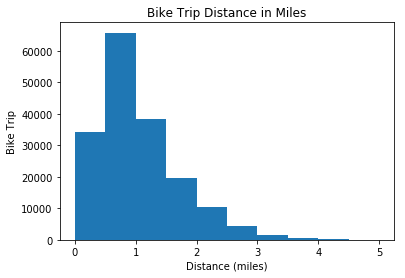

```python
# now, let's look at the trip distance in miles
bins = np.arange(0, 5+0.5, 0.5)

plt.hist(data = bike, x = 'distance_miles', bins = bins);

plt.title('Bike Trip Distance in Miles')
plt.xlabel('Distance (miles)')
plt.ylabel('Bike Trip')
plt.show()
```

## Most Popular Start Stations

Market St is the most popular start station followed by San Francisco Caltrain Station 2.

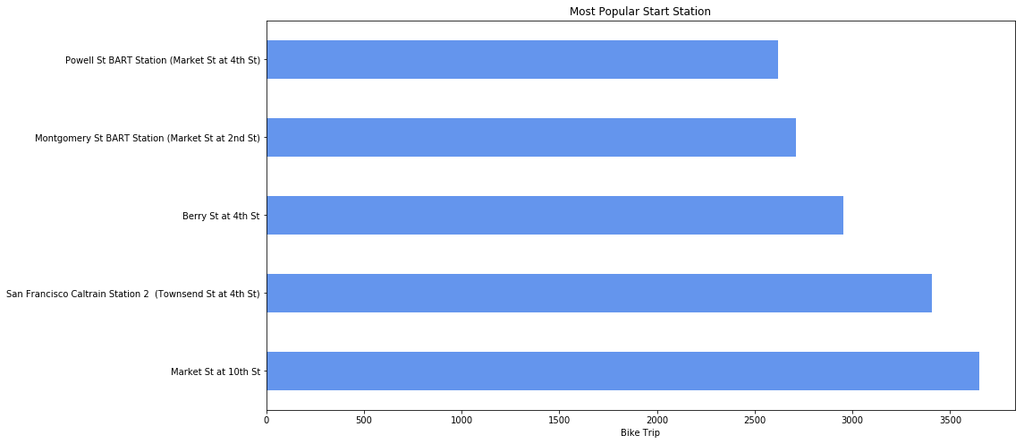

```python
start_station_count.plot('barh', figsize=(15,8), color = 'cornflowerblue', title='Most Popular Start Station').set_xlabel("Bike Trip");
```

## Most Popular End Stations

San Francisco Caltrain Station 2 is observed to overtake Market St as the most popular end station.

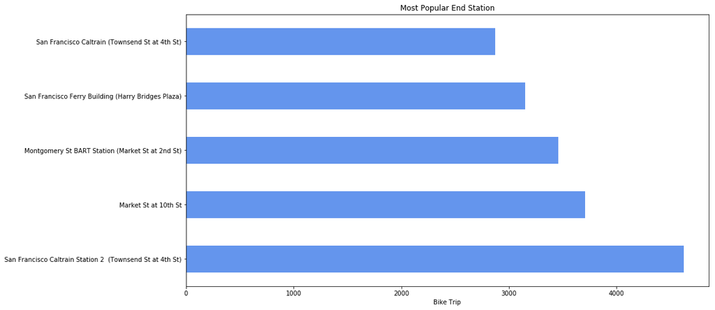

```python
end_station_count.plot('barh', figsize=(15,8), color = 'cornflowerblue', title='Most Popular End Station').set_xlabel("Bike Trip");
```

## Relationship in Users and Their Behviours I

#### Weekday vs. User Type

The trip number of subscribers is much higher than customers.

#### Weekday vs. Member Gender

Male complete 2 times or more trips as female.

#### Weeday vs. Bike Share for All Trip

Bike share for all trip by users are very low compare to users that do not use bike share for all trip

#### Weekday vs. Age Group

Users between the ages (25-40) called Millennials use bike share the most in all weekdays

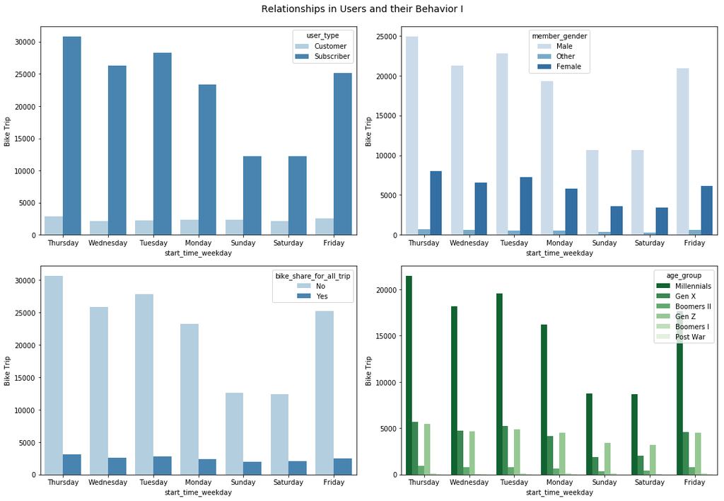

```python
# plot the relationship between categorical variables
fig, ((ax1, ax2), (ax3, ax4)) = plt.subplots(nrows=2, ncols=2, figsize = [15,10])
plt.suptitle('Relationships in Users and their Behavior I', fontsize=14, y=1.025)

# subplot 1: weekday vs user type
plt.subplot(2, 2, 1)
sb.countplot(data = bike, x = 'start_time_weekday', hue = 'user_type', palette = 'Blues')
plt.ylabel('Bike Trip')

# subplot 2: weekday vs. member gender
plt.subplot(2, 2, 2)
sb.countplot(data = bike, x = 'start_time_weekday', hue = 'member_gender', palette = 'Blues')
plt.ylabel('Bike Trip')

# subplot 3: weekday vs. , bike share for all trip
plt.subplot(2, 2, 3)
sb.countplot(data = bike, x = 'start_time_weekday', hue = 'bike_share_for_all_trip', palette = 'Blues')
plt.ylabel('Bike Trip')


# subplot 3: weekday vs.age group
plt.subplot(2, 2, 4)
sb.countplot(data = bike, x = 'start_time_weekday', hue = 'age_group', palette = 'Greens_r')
plt.ylabel('Bike Trip')

plt.tight_layout()
```

## Relationship in Users and Their Behviours II

#### Member Gender vs. Age Group

There are more males than females and other genders. Both male and female gender have more users in the age group called Millennials

#### Age Group vs. Member Gender

Males dominate more in all the age groups

#### User Type vs. Member Gender

Males are the highest gender of users both as customers and as subscribers

#### Member Gender vs. User Type

Subcribers in male are more than in female, followed by other gender

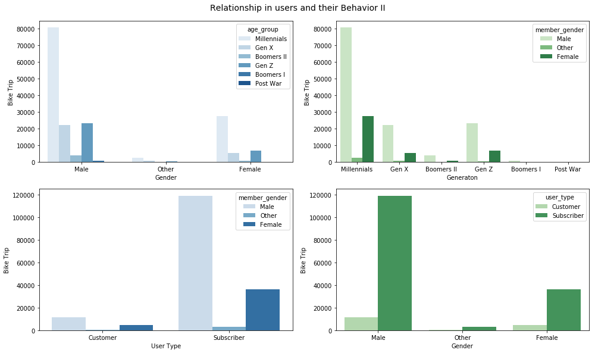

```python
# plot the relationship between categorical variables
fig, ((ax1, ax2), (ax3, ax4)) = plt.subplots(nrows=2, ncols=2,figsize = [14,8])
base_color = sb.color_palette()[0]
plt.suptitle('Relationship in users and their Behavior II', fontsize=14, y=1.025)

ax1 = plt.subplot(2,2,1)
ax1=sb.countplot(data = bike, x = 'member_gender', hue = 'age_group', palette = 'Blues')
ax1= plt.xlabel("Gender")
ax1= plt.ylabel('Bike Trip')

ax2 = plt.subplot(2,2,2)
ax2=sb.countplot(data = bike, x = 'age_group', hue = 'member_gender', palette = 'Greens')
ax2= plt.xlabel("Generaton")
ax2= plt.ylabel('Bike Trip')


ax3 = plt.subplot(2,2,3)
ax3=sb.countplot(data = bike, x = 'user_type', hue = 'member_gender', palette = 'Blues')
ax3= plt.xlabel('User Type')
ax3= plt.ylabel('Bike Trip')

ax4 = plt.subplot(2,2,4)
ax4=sb.countplot(data = bike, x = 'member_gender' , hue = 'user_type', palette = 'Greens')
ax4= plt.xlabel("Gender")
ax4= plt.ylabel('Bike Trip')

plt.tight_layout()
```

## Duration and Distance by User Type

From the faceted heat maps below, It is observed that there is an effect of user type on the relationship between usage duration in seconds and distance in miles.

For user type, customers tend to go on a long trip, that is, they use bike share for long durations and distances as compared to subscribers, whose trips are in short duration and distance. The more focused aspect in subscribers also revealed that subscribers are looking for a consistent experience, which is daily commute as compared to customers which use bike share for different purposes.

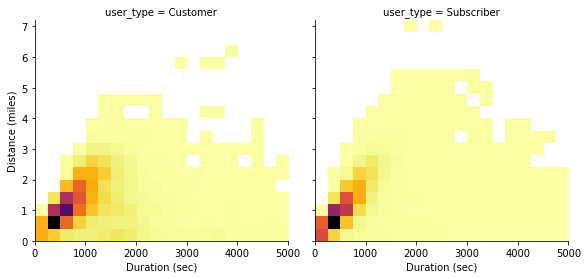

```python
# create faceted heat maps on user_type
g = sb.FacetGrid(data = bike, col = 'user_type', col_wrap = 3, size = 4)

g.map(hist2dgrid, 'duration_sec', 'distance_miles', color = 'inferno_r')
g.set_xlabels('Duration (sec)')
g.set_ylabels('Distance (miles)')

plt.show()
```

## Duration by User Type and Age

Here, age does not have any effect in predicting demand using bike duration of trip. Instead, there is a significant difference in duration of trip between subscriber and customer. Subscriber generally uses bike for short distance trip and short duration trip unlike Customer that uses bike for long distance trip and duration trip.

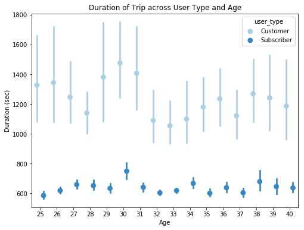

```python
# setting the figure size
fig = plt.figure(figsize = [8,6])
# point plot of age against duration with user_type
ax = sb.pointplot(data = df_plot, x = 'member_age', y = 'duration_sec', hue = 'user_type',
                  palette = 'Blues', linestyles = '', dodge = 0.4)
plt.title('Duration of Trip across User Type and Age')
plt.ylabel('Duration (sec)')
plt.xlabel('Age')
ax.set_yticklabels([],minor = True)
plt.show();
```

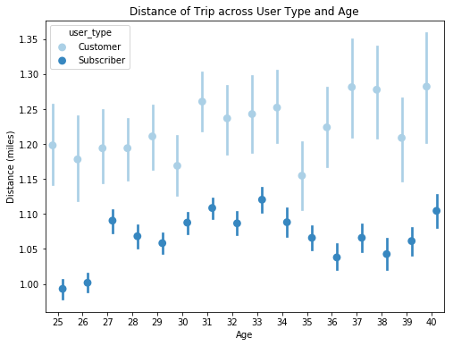

```python
# set the figure size
fig = plt.figure(figsize = [8,6])
# point plot of age against duration with user_type
ax = sb.pointplot(data = df_plot, x = 'member_age', y = 'distance_miles', hue = 'user_type',
                  palette = 'Blues', linestyles = '', dodge = 0.4)
plt.title('Distance of Trip across User Type and Age')
plt.ylabel('Distance (miles)')
plt.xlabel('Age')
ax.set_yticklabels([],minor = True)
plt.show();
```

## Duration by Weekday and User Type

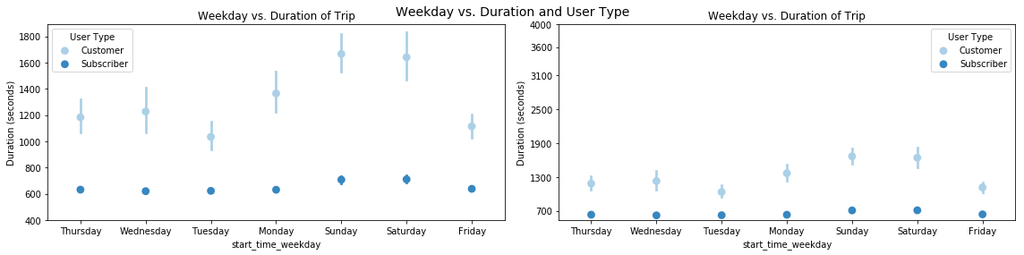

```python
# plot the interactions between categorical variables and numeric variable
plt.figure(figsize = [16, 4])
plt.suptitle("Weekday vs. Duration and User Type", fontsize = 14)

ax1=plt.subplot(1,2, 1)
ax1=sb.pointplot(data = bike, x= 'start_time_weekday', y = 'duration_sec',
                 hue = 'user_type', palette = 'Blues', linestyles = '')
ax1=plt.ylabel('Duration (seconds)')
ax1=plt.title('Weekday vs. Duration of Trip')
ax1=plt.yticks([400, 600, 800, 1000, 1200, 1400, 1600, 1800]) # 30 minutes
ax1=plt.legend(title='User Type')

ax2=plt.subplot(1, 2, 2)
ax2=sb.pointplot(data = bike, x= 'start_time_weekday', y = 'duration_sec',
                 hue = 'user_type', palette = 'Blues', linestyles = '')
ax2=plt.ylabel('Duration (seconds)')
ax2=plt.title('Weekday vs. Duration of Trip')
ax2=plt.yticks([700,1.3e3, 1.9e3, 2.5e3, 3.1e3, 3.6e3, 4e3])
ax2=plt.legend(title='User Type')

plt.tight_layout()
```

## Duration by Weekday and Age Group

There are more short time trips on working days (Mon-Fri). The duration of trip of age range Gen Z, Millennials and Gen X is more stable than the older range. These have higher variation.

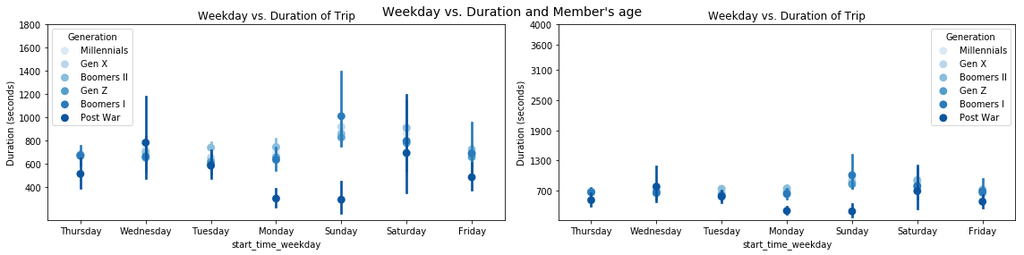

```python
# plot the interactions between categorical variables and numeric variable
plt.figure(figsize = [16, 4])
plt.suptitle("Weekday vs. Duration and Member's age", fontsize = 14)

ax1=plt.subplot(1,2, 1)
ax1=sb.pointplot(data = bike, x= 'start_time_weekday', y = 'duration_sec',
                 hue = 'age_group', palette = 'Blues', linestyles = '')
ax1=plt.ylabel('Duration (seconds)')
ax1=plt.title('Weekday vs. Duration of Trip')
ax1=plt.yticks([400, 600, 800, 1000, 1200, 1400, 1600, 1800]) # 30 minutes
ax1=plt.legend(title='Generation')

ax2=plt.subplot(1, 2, 2)
ax2=sb.pointplot(data = bike, x= 'start_time_weekday', y = 'duration_sec',
                 hue = 'age_group', palette = 'Blues', linestyles = '')
ax2=plt.ylabel('Duration (seconds)')
ax2=plt.title('Weekday vs. Duration of Trip')
ax2=plt.yticks([700,1.3e3, 1.9e3, 2.5e3, 3.1e3, 3.6e3, 4e3])
ax2=plt.legend(title='Generation')

plt.tight_layout()
```